# Predicting Stroke Risk

## Phase 2: Predictive Modelling

### Group Name: 10

#### Name(s) & ID(s) of Group Members:

- Nopphasorn Chuaydumrongsakul (S3868578)
- Matikorn Inprom (S3930892)
- Sukhum Boondecharak (S3940976)

## `Table of Contents`

- Introduction
  - Phase 1 Summary
  - Report Overview
  - Overview of Methodology
- Data Preparation
  - Splitting Data
  - Encoding Data
  - Normalising Data
- Predictive Modelling
  - Feature Selection (FS)
  - Model Fitting & Tuning
    - KNN with Three Parameters Tuning
    - DecisionTree with Three Parameters Tuning
    - Random Forest with Three Parameters Tuning
    - Naive Bayes with One Parameter Tuning
    - Logistic Regression with Three Parameters Tuning
    - Neural Network Model Fitting & Tuning
  - Model Comparison
- Critique & Limitations
- Summary and Conclusions
  - Project Summary
  - Summary of Findings
  - Conclusions
- References

## `Introduction`

### Phase 1 Summary

In phase 1 of our project, we focused mainly on data cleaning, data preprocessing, and data exploration using a dataset sourced from [Kaggle](https://www.kaggle.com/datasets/fedesoriano/stroke-prediction-dataset/data) (FEDESORIANO, 2021) with various attributes, including `gender`, `age`, `hypertension`, `heart disease`, `marital status`, `work type`, `residence type`, `average glucose level`, `BMI`, and `smoking status`. Our primary objective was to understand the relationships between these factors and the incidence of strokes.

We kicked off by standardising the data, which included normalising names and removing irrelevant variables, which were not necessary for predictive modelling. We also addressed missing values and outliers, removing observations with 'other' gender values and null values in the BMI column. The dataset size was already appropriate for analysis, so no further data sampling was performed.

For data exploration, we employed data visualisation and analysis to identify patterns, correlations, and insights that could improve stroke prediction. Our visualisations revealed that stroke patients were predominantly in their seventies or older and that there was a significant association between heart disease and stroke. We also noted that most patients had never smoked, with fewer individuals currently smoking or having smoked in the past.

Further examination showed that individuals who suffered a stroke generally had higher BMI, elevated average blood glucose levels, and were older compared to those who had not experienced a stroke. These factors are critical as advanced age, increased BMI, and higher blood glucose levels are associated with a greater risk of stroke. Monitoring and managing these parameters are vital for stroke prevention and overall well-being.

Overall, the data visualisations not only improved our understanding of the interplay between various factors and stroke risk but also helped in effectively communicating these insights to stakeholders. This sets the foundation for Phase 2, where we will develop and evaluate predictive models for long-term stroke risk prediction.

### Report Overview

As our ultimate goal was to identify the most effective algorithm for predicting stroke risk and understand the key features influencing these predictions, we began by retrieving cleaned dataset from phase 1 and proceed on further preparations. Given that the data contained categorical variables, we applied encoding techniques to convert them into numerical formats. Additionally, normalisation was performed to scale the features, ensuring uniformity and better performance of machine learning algorithms.

Furthermore, we performed feature selection to identify which features had the most influence on stroke prediction. Initially, we used `Random Forest` to assess feature importance, which provided insights into the most significant predictors such as avg_glucose_level, bmi, and age. These features had significantly higher importance scores compared to others, providing valuable insights into which variables are critical for accurate predictions.

Upon examining the target variable, we discovered a significant class imbalance, with the minority class representing only 4.26% of the data. To address this, we applied the `Synthetic Minority Over-sampling Technique (SMOTE)`, which created synthetic samples for the minority class, effectively balancing the dataset and mitigating potential biases in the model training process. (SWASTIK SATPATHY, 2023)

With a balanced and preprocessed dataset, we applied multiple machine learning algorithms to build predictive models. The algorithms used included K-Nearest Neighbors (KNN), Decision Tree, Random Forest, Naive Bayes, and Logistic Regression. To ensure optimal performance, we performed hyperparameter tuning using `GridSearchCV`, which involved searching for the best parameters within specified ranges for each model. (Rahul Shah, 2024) This tuning process was combined with 5-fold cross-validation to provide a robust evaluation of model performance.

Each model's performance was primarily evaluated using the `ROC-AUC` metric, a robust measure for classification tasks, especially in the context of imbalanced datasets. (Jason Brownlee, 2021) As a result, it turned out the Random Forest model achieved the highest ROC-AUC score among other models, indicating its superior performance in predicting stroke risk. To statistically compare the models, we conducted paired t-tests. These tests revealed significant differences between most model pairs, confirming the superior performance of Random Forest.

While the project successfully identified the best-performing model and key predictors for given dataset, it also acknowledged limitations such as potential overfitting, computational costs associated with hyperparameter tuning, and assumptions in statistical tests. Future work could explore more advanced models, broader hyperparameter searches, and additional data preprocessing techniques to further enhance model performance and robustness.

### Overview of Methodology

The methodology for this project involved several key steps. Initially, the features were encoded and normalised to achieve uniformity, which is crucial for the performance of machine learning algorithms. Feature selection was conducted using the `Random Forest` model to determine and visualise the importance scores of various features, highlighting `avg_glucose_level`, `bmi`, and `age` as the key predictors of stroke risk.

Given the significant class imbalance in the target variable, we applied the `Synthetic Minority Over-sampling Technique (SMOTE)`. This technique created synthetic samples for the minority class, effectively balancing the dataset and improving the reliability of our model predictions.

For model selection and training, we employed five different algorithms: `K-Nearest Neighbours (KNN)`, `Decision Tree`, `Random Forest`, `Naive Bayes`, and `Logistic Regression`. We utilised `GridSearchCV` for hyperparameter tuning, ensuring that each model was optimised for the best performance. And to robustly evaluate the models, we used 5-fold cross-validation.

Performance evaluation was primarily based on `ROC-AUC` scores, providing a robust measure of model performance, particularly for imbalanced datasets. To identify statistically significant differences between the models, we conducted `paired t-tests`.

To simplify interpretation, we created various visualisations. Bar plots were used to compare the ROC-AUC scores of different models, while feature importance plots illustrated the contribution of top features in the Random Forest model.

[Back to Table of Contents](#back)

## `Data Preparation`

We begin by importing several essential libraries and configuring the display settings to enhance the quality of our plots. We also suppress any unnecessary warnings to ensure a smooth workflow. Next, we will load our dataset, `Phase2_Group10.csv`, which underwent initial cleaning in phase 1, using pandas, and perform initial inspections by displaying the first few rows and checking the volume of the data.

```python
import pandas as pd
import numpy as np
from scipy import stats
import matplotlib.pyplot as plt
import seaborn as sns

import matplotlib.pyplot as plt
%matplotlib inline
%config InlineBackend.figure_format = 'retina'
plt.style.use("ggplot")

import warnings
warnings.filterwarnings("ignore")
```

```python
data = pd.read_csv('Phase2_Group10.csv')
data.head()
```

|  | gender | age | hypertension | heart_disease | marital_status | work_type | residence_type | avg_glucose_level | bmi | smoking_status | stroke |
| --- | --- | --- | --- | --- | --- | --- | --- | --- | --- | --- | --- |
| 0 | male | 67.0 | 0 | 1 | yes | private | urban | 228.69 | 36.6 | formerly smoked | 1 |
| 1 | male | 80.0 | 0 | 1 | yes | private | rural | 105.92 | 32.5 | never smoked | 1 |
| 2 | female | 49.0 | 0 | 0 | yes | private | urban | 171.23 | 34.4 | smokes | 1 |
| 3 | female | 79.0 | 1 | 0 | yes | self-employed | rural | 174.12 | 24.0 | never smoked | 1 |
| 4 | male | 81.0 | 0 | 0 | yes | private | urban | 186.21 | 29.0 | formerly smoked | 1 |

```python
data.shape
```

```
(4908, 11)
```

[Back to Table of Contents](#back)

### Splitting Data

We then split the features into `target` and `data` by separating the target feature from the stroke column and dropping the column to prepare descriptive features. We also verify some of the data using random samples.

```python
target = data['stroke']
data.drop(columns = ['stroke'],inplace = True)
```

```python
print(target.shape)
print(data.shape)
```

```
(4908,)
(4908, 10)
```

```python
target.sample(10, random_state = 60)
```

```
3291    0
2300    0
2281    0
3828    0
1388    0
605     0
1669    0
52      1
4152    0
146     1
Name: stroke, dtype: int64
```

```python
data.head()
```

|  | gender | age | hypertension | heart_disease | marital_status | work_type | residence_type | avg_glucose_level | bmi | smoking_status |
| --- | --- | --- | --- | --- | --- | --- | --- | --- | --- | --- |
| 0 | male | 67.0 | 0 | 1 | yes | private | urban | 228.69 | 36.6 | formerly smoked |
| 1 | male | 80.0 | 0 | 1 | yes | private | rural | 105.92 | 32.5 | never smoked |
| 2 | female | 49.0 | 0 | 0 | yes | private | urban | 171.23 | 34.4 | smokes |
| 3 | female | 79.0 | 1 | 0 | yes | self-employed | rural | 174.12 | 24.0 | never smoked |
| 4 | male | 81.0 | 0 | 0 | yes | private | urban | 186.21 | 29.0 | formerly smoked |

[Back to Table of Contents](#back)

### Encoding Data

Since target feature is already in categorical value separating positive values from negative values using 1 and 0 respectively, we do not need to do integer encoding for this matter. The descriptive features, on the other hand, need much more attention for value encoding because some features are not in numerical format. In this case, we will apply `One-hot Encoding` method.

#### Target Feature

We simply convert the target feature from a pandas Series to a NumPy array.

```python
target = target.values
target
```

```
array([1, 1, 1, ..., 0, 0, 0])
```

#### Descriptive Features

For descriptive features, we inspect and modify data types, particularly converting `hypertension` and `heart_disease` columns to categorical types. We identify all categorical columns and examined their unique values and distributions. We then apply one-hot encoding to transform categorical variables into a suitable format for machine learning models while ensuring to keep the original dataframe for further analysis. Finally, we check the shape of the encoded dataframe and preview the first few rows to verify the encoding process.

```python
data
```

|  | gender | age | hypertension | heart_disease | marital_status | work_type | residence_type | avg_glucose_level | bmi | smoking_status |
| --- | --- | --- | --- | --- | --- | --- | --- | --- | --- | --- |
| 0 | male | 67.0 | 0 | 1 | yes | private | urban | 228.69 | 36.6 | formerly smoked |
| 1 | male | 80.0 | 0 | 1 | yes | private | rural | 105.92 | 32.5 | never smoked |
| 2 | female | 49.0 | 0 | 0 | yes | private | urban | 171.23 | 34.4 | smokes |
| 3 | female | 79.0 | 1 | 0 | yes | self-employed | rural | 174.12 | 24.0 | never smoked |
| 4 | male | 81.0 | 0 | 0 | yes | private | urban | 186.21 | 29.0 | formerly smoked |
| ... | ... | ... | ... | ... | ... | ... | ... | ... | ... | ... |
| 4903 | female | 13.0 | 0 | 0 | no | never_worked | rural | 103.08 | 18.6 | unknown |
| 4904 | female | 81.0 | 0 | 0 | yes | self-employed | urban | 125.20 | 40.0 | never smoked |
| 4905 | female | 35.0 | 0 | 0 | yes | self-employed | rural | 82.99 | 30.6 | never smoked |
| 4906 | male | 51.0 | 0 | 0 | yes | private | rural | 166.29 | 25.6 | formerly smoked |
| 4907 | female | 44.0 | 0 | 0 | yes | govt_job | urban | 85.28 | 26.2 | unknown |

4908 rows × 10 columns

```python
data.dtypes
```

```
gender                object
age                  float64
hypertension           int64
heart_disease          int64
marital_status        object
work_type             object
residence_type        object
avg_glucose_level    float64
bmi                  float64
smoking_status        object
dtype: object
```

```python
data['hypertension'] = data['hypertension'].astype(object)
data['heart_disease'] = data['heart_disease'].astype(object)
data.dtypes
```

```
gender                object
age                  float64
hypertension          object
heart_disease         object
marital_status        object
work_type             object
residence_type        object
avg_glucose_level    float64
bmi                  float64
smoking_status        object
dtype: object
```

```python
categorical_cols = data.columns[data.dtypes == object].tolist()

for categorical_col in categorical_cols:
    print(categorical_col.capitalize() + ':')
    print(f'Number of Uniques: {data[categorical_col].nunique()}')
    print(data[categorical_col].value_counts(normalize=True).mul(100).round(2))
    print('\n')
```

```
Gender:
Number of Uniques: 2
female    59.03
male      40.97
Name: gender, dtype: float64


Hypertension:
Number of Uniques: 2
0    90.81
1     9.19
Name: hypertension, dtype: float64


Heart_disease:
Number of Uniques: 2
0    95.05
1     4.95
Name: heart_disease, dtype: float64


Marital_status:
Number of Uniques: 2
yes    65.28
no     34.72
Name: marital_status, dtype: float64


Work_type:
Number of Uniques: 4
private          57.25
self-employed    15.79
never_worked     14.12
govt_job         12.84
Name: work_type, dtype: float64


Residence_type:
Number of Uniques: 2
urban    50.73
rural    49.27
Name: residence_type, dtype: float64


Smoking_status:
Number of Uniques: 4
never smoked       37.73
unknown            30.22
formerly smoked    17.03
smokes             15.02
Name: smoking_status, dtype: float64
```

```python
# maintain original Data without encoding for further analysis
data_encoded = data.copy()

data_encoded = pd.get_dummies(data_encoded)
col_names = data_encoded.columns
```

```python
data_encoded.shape
```

```
(4908, 21)
```

```python
data_encoded.head()
```

|  | age | avg_glucose_level | bmi | gender_female | gender_male | hypertension_0 | hypertension_1 | heart_disease_0 | heart_disease_1 | marital_status_no | ... | work_type_govt_job | work_type_never_worked | work_type_private | work_type_self-employed | residence_type_rural | residence_type_urban | smoking_status_formerly smoked | smoking_status_never smoked | smoking_status_smokes | smoking_status_unknown |
| --- | --- | --- | --- | --- | --- | --- | --- | --- | --- | --- | --- | --- | --- | --- | --- | --- | --- | --- | --- | --- | --- |
| 0 | 67.0 | 228.69 | 36.6 | 0 | 1 | 1 | 0 | 0 | 1 | 0 | ... | 0 | 0 | 1 | 0 | 0 | 1 | 1 | 0 | 0 | 0 |
| 1 | 80.0 | 105.92 | 32.5 | 0 | 1 | 1 | 0 | 0 | 1 | 0 | ... | 0 | 0 | 1 | 0 | 1 | 0 | 0 | 1 | 0 | 0 |
| 2 | 49.0 | 171.23 | 34.4 | 1 | 0 | 1 | 0 | 1 | 0 | 0 | ... | 0 | 0 | 1 | 0 | 0 | 1 | 0 | 0 | 1 | 0 |
| 3 | 79.0 | 174.12 | 24.0 | 1 | 0 | 0 | 1 | 1 | 0 | 0 | ... | 0 | 0 | 0 | 1 | 1 | 0 | 0 | 1 | 0 | 0 |
| 4 | 81.0 | 186.21 | 29.0 | 0 | 1 | 1 | 0 | 1 | 0 | 0 | ... | 0 | 0 | 1 | 0 | 0 | 1 | 1 | 0 | 0 | 0 |

5 rows × 21 columns

[Back to Table of Contents](#back)

### Normalising Data

After it has been encoded, we normalise the data using `MinMaxScaler` to scale all features between 0 and 1. We start by importing and initialising the `MinMaxScaler` from `sklearn`. We then apply it to the data encoded from the previous step, transforming it into a scaled NumPy array. This normalised array was converted back into a dataframe for better readability and verification, and then into an array for further analysis and modelling. This normalisation step ensures that all features contribute equally to the machine learning models, preventing features with larger ranges from dominating the learning process.

```python
from sklearn import preprocessing
Data_scaler = preprocessing.MinMaxScaler()
data_encoded_norm_numpy = Data_scaler.fit_transform(data_encoded)
```

```python
data_norm = pd.DataFrame(data_encoded_norm_numpy, columns=col_names)
data_norm.head()
```

|  | age | avg_glucose_level | bmi | gender_female | gender_male | hypertension_0 | hypertension_1 | heart_disease_0 | heart_disease_1 | marital_status_no | ... | work_type_govt_job | work_type_never_worked | work_type_private | work_type_self-employed | residence_type_rural | residence_type_urban | smoking_status_formerly smoked | smoking_status_never smoked | smoking_status_smokes | smoking_status_unknown |
| --- | --- | --- | --- | --- | --- | --- | --- | --- | --- | --- | --- | --- | --- | --- | --- | --- | --- | --- | --- | --- | --- |
| 0 | 0.816895 | 0.801265 | 0.301260 | 0.0 | 1.0 | 1.0 | 0.0 | 0.0 | 1.0 | 0.0 | ... | 0.0 | 0.0 | 1.0 | 0.0 | 0.0 | 1.0 | 1.0 | 0.0 | 0.0 | 0.0 |
| 1 | 0.975586 | 0.234512 | 0.254296 | 0.0 | 1.0 | 1.0 | 0.0 | 0.0 | 1.0 | 0.0 | ... | 0.0 | 0.0 | 1.0 | 0.0 | 1.0 | 0.0 | 0.0 | 1.0 | 0.0 | 0.0 |
| 2 | 0.597168 | 0.536008 | 0.276060 | 1.0 | 0.0 | 1.0 | 0.0 | 1.0 | 0.0 | 0.0 | ... | 0.0 | 0.0 | 1.0 | 0.0 | 0.0 | 1.0 | 0.0 | 0.0 | 1.0 | 0.0 |
| 3 | 0.963379 | 0.549349 | 0.156930 | 1.0 | 0.0 | 0.0 | 1.0 | 1.0 | 0.0 | 0.0 | ... | 0.0 | 0.0 | 0.0 | 1.0 | 1.0 | 0.0 | 0.0 | 1.0 | 0.0 | 0.0 |
| 4 | 0.987793 | 0.605161 | 0.214204 | 0.0 | 1.0 | 1.0 | 0.0 | 1.0 | 0.0 | 0.0 | ... | 0.0 | 0.0 | 1.0 | 0.0 | 0.0 | 1.0 | 1.0 | 0.0 | 0.0 | 0.0 |

5 rows × 21 columns

```python
data_numpy = data_norm.values
```

[Back to Table of Contents](#back)

## `Predictive Modelling`

### Feature Selection (FS)

Now, let's look at the most important 10 features as selected by Random Forest Importance (RFI) in the full dataset.

We set up the `RandomForestClassifier` with 100 trees to model the data. We want to identify the top 10 most important features. We then train the Random Forest model using the normalised dataset (`data_norm`) and the target labels (`target`). After training, we extract the indices of the top 10 features based on their importance scores. We then retrieved the names of these top features and stored their corresponding importance scores.

To visualise the results, we define a function called plot_imp that creates a horizontal bar plot of feature importances. We used this function to plot the importance scores of the top 10 features, clearly showing which features are most influential in predicting stroke risk according to the Random Forest model.

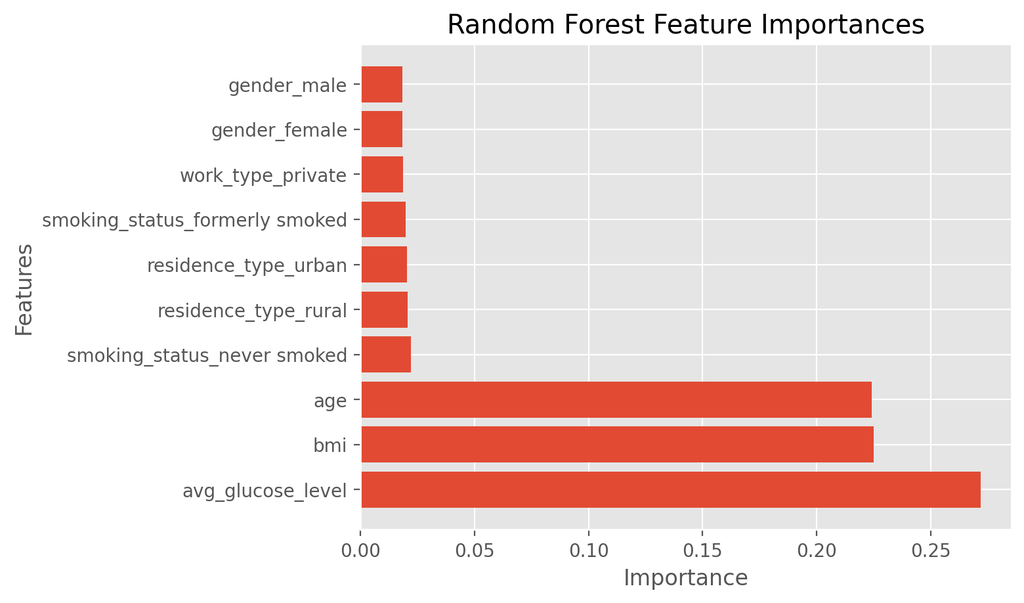

```
Feature: avg_glucose_level, Importance Score: 0.2718
Feature: bmi, Importance Score: 0.2249
Feature: age, Importance Score: 0.2242
Feature: smoking_status_never smoked, Importance Score: 0.0223
Feature: residence_type_rural, Importance Score: 0.0207
Feature: residence_type_urban, Importance Score: 0.0204
Feature: smoking_status_formerly smoked, Importance Score: 0.0198
Feature: work_type_private, Importance Score: 0.0188
Feature: gender_female, Importance Score: 0.0185
Feature: gender_male, Importance Score: 0.0185
```

```python
from sklearn.ensemble import RandomForestClassifier
import matplotlib.pyplot as plt

# Train the Random Forest model
num_features = 10
model_rfi = RandomForestClassifier(n_estimators=100, random_state=999)
model_rfi.fit(data_norm, target)

# Extract the indices of the top 10 features
fs_indices_rfi = np.argsort(model_rfi.feature_importances_)[::-1][0:num_features]

# Retrieve the names of these top features and their importance scores
best_features_rfi = data_norm.columns[fs_indices_rfi].values
feature_importances_rfi = model_rfi.feature_importances_[fs_indices_rfi]

# Visualise the feature importances
def plot_imp(best_features, scores, method_name):
    plt.barh(best_features, scores)
    plt.title(method_name + ' Feature Importances')
    plt.xlabel("Importance")
    plt.ylabel("Features")
    plt.show()

plot_imp(best_features_rfi, feature_importances_rfi, 'Random Forest')

# Print the top 10 features and their importance scores
for feature, importance in zip(best_features_rfi, feature_importances_rfi):
    print(f'Feature: {feature}, Importance Score: {importance:.4f}')
```

As a result, `Avg Glucose Level`, `BMI`, and `Age` have the highest importance scores and should be key predictors in our models. Other categorical features like `Smoking Status`, `Residence Type`, and `Gender` also suggests that these factors play a role in predicting stroke risk. Therefore, we will evaluate which model performs best with these selected features.

```python
# Select the top features based on the importance scores
top_features = best_features_rfi
data_top_features = data_norm[top_features]
```

### Model Fitting & Tuning

To understand the balance of our dataset, we first examine the distribution of the target labels.

```python
pd.Series(target).value_counts(normalize=True).mul(100).round(2)
```

```
0    95.74
1     4.26
dtype: float64
```

While 95.74% of the data have a target value of 0, only 4.26% have a target value of 1. This points out the distribution imbalance in the target variable. This imbalance can significantly impact the performance of machine learning models, specifically those sensitive to class distribution, such as classifiers. In this case, we will use `Synthetic Minority Over-sampling Technique (SMOTE)` to generate synthetic samples for the minority class to balance the dataset.

We then split the normalised dataset based on selected features (`data_top_features`) and target labels (`target`) into training and testing sets using a 70/30 split, ensuring consistency with a set random state. To evaluate our models, we defined a cross-validation method (`cv_method_train`) using `StratifiedKFold` with five splits, which helps maintain the proportion of target classes in each fold. Then, we will set the evaluation metric to `roc_auc` to address the class imbalance in our classification task. Finally, we will import models to be fitted, as well as `GridSearchCV` for hyperparameter tuning.

```python
from sklearn.model_selection import train_test_split, StratifiedKFold
from sklearn.neighbors import KNeighborsClassifier
from sklearn.tree import DecisionTreeClassifier
from sklearn.ensemble import RandomForestClassifier
from sklearn.naive_bayes import GaussianNB
from sklearn.linear_model import LogisticRegression
from sklearn.model_selection import GridSearchCV

# Split the dataset into training and testing sets
D_train, D_test, T_train, T_test = train_test_split(data_top_features, target, test_size=0.3, random_state=999)

cv_method_train = StratifiedKFold(n_splits=5, shuffle=True, random_state=999)

# using roc_auc for our imbalanced classification
scoring_metric = 'roc_auc'
```

```python
# Install imbalanced-learn (only need to run once)
!pip install imbalanced-learn
```

```python
from imblearn.over_sampling import SMOTE

# Apply SMOTE to the training data
smote = SMOTE(random_state=999)
D_train_smote, T_train_smote = smote.fit_resample(D_train, T_train)
```

```python
# Check the distribution before applying SMOTE
pd.Series(T_train).value_counts(normalize=True).mul(100).round(2)
```

```
0    95.57
1     4.43
dtype: float64
```

```python
# Check the distribution after applying SMOTE
pd.Series(T_train_smote).value_counts(normalize=True).mul(100).round(2)
```

```
0    50.0
1    50.0
dtype: float64
```

As shown above, SMOTE is applied to generate synthetic samples for the minority class in the training data, resulting in a balanced dataset. Going forward, we will be using `D_train_smote` and `T_train_smote` to fit the models.

[Back to Table of Contents](#back)

#### KNN with Three Parameters Tuning

We perform hyperparameter tuning for the `K-Nearest Neighbors Classifier` using `GridSearchCV`. We define a range of parameters to search, including the `number of neighbors`, `distance metric (p)`, and `weights`. The GridSearchCV is configured to use cross-validation method and the `roc_auc` scoring metric. After fitting the model on the training data, we identify the best parameters and the corresponding score.

```python
# Define the KNN classifier
knn_classifier = KNeighborsClassifier()

# Define the hyperparameter grid
params_KNN = {'n_neighbors': [1, 3, 5, 7, 9],
              'p': [1, 2, 3],
              'weights': ['uniform', 'distance']}

# Initialise GridSearchCV
gs_KNN = GridSearchCV(estimator=knn_classifier,
                      param_grid=params_KNN,
                      cv=cv_method_train,
                      scoring=scoring_metric,
                      verbose=1,
                      n_jobs=-1)

# Perform GridSearchCV
gs_KNN.fit(D_train_smote, T_train_smote)

# Print best parameters and best score
print(f'The best parameters of K-Neighbors Classifier are: {gs_KNN.best_params_}')
print(f'With the best score using {scoring_metric} as the metric is: {round(gs_KNN.best_score_, 3)}')
```

```
Fitting 5 folds for each of 30 candidates, totalling 150 fits
The best parameters of K-Neighbors Classifier are: {'n_neighbors': 9, 'p': 1, 'weights': 'distance'}
With the best score using roc_auc as the metric is: 0.961
```

As a result, the `K-Nearest Neighbors Classifier` with `9 neighbours`, using the `Manhattan distance (p=1)` and `weighted by distance`, achieved a high ROC-AUC score of 0.961, indicating excellent performance in distinguishing between classes.

Then, we will create a dataframe to store the results, including the tested parameters and their mean test scores. We will also visualise the performance of different configurations of the K-Neighbors Classifier using a line plot, which illustrates the relationship between the number of neighbours, score, weights, and distance metric (p).

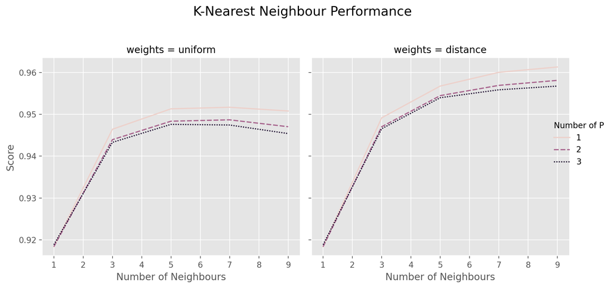

```python
results_KNN = pd.DataFrame.from_dict(gs_KNN.cv_results_['params'])
results_KNN['score'] = gs_KNN.cv_results_['mean_test_score']

rel_plot = sns.relplot(
    data=results_KNN, x="n_neighbors", y="score",
    col="weights", hue="p", style="p",
    kind="line"
)
rel_plot.axes[0,0].set_xlabel('Number of Neighbours')
rel_plot.axes[0,1].set_xlabel('Number of Neighbours')
rel_plot.axes[0,0].set_ylabel('Score')
rel_plot._legend.set_title("Number of P")
rel_plot._legend._legend_box.align = "left"
rel_plot.fig.subplots_adjust(top=0.8)
rel_plot.fig.suptitle('K-Nearest Neighbour Performance', fontsize=16)
plt.show(rel_plot)
```

[Back to Table of Contents](#back)

#### DecisionTree with Three Parameters Tuning

We also conduct hyperparameter tuning for the `Decision Tree Classifier` using `GridSearchCV`. In this case, the parameter grid includes different values for `maximum depth`, `minimum samples split`, and `criterion`. GridSearchCV is also set up with cross-validation method and the `roc_auc` scoring metric. After training the model on the training data, we identify the best parameters and the corresponding score.

```python
# Define the Decision Tree classifier
dt_classifier = DecisionTreeClassifier(random_state=999)

# Define the hyperparameter grid
params_DT = {'max_depth': [3, 5, 7, 10, 12],
             'min_samples_split': [2, 5, 15, 20, 25],
             'criterion': ['gini', 'entropy']}

# Initialise GridSearchCV
gs_DT = GridSearchCV(estimator=dt_classifier,
                     param_grid=params_DT,
                     cv=cv_method_train,
                     scoring=scoring_metric,
                     verbose=1,
                     n_jobs=-1)

# Perform GridSearchCV
gs_DT.fit(D_train_smote, T_train_smote)

# Print best parameters and best score
print(f'The best parameters of Decision Tree Classifier are: {gs_DT.best_params_}')
print(f'With the best score using {scoring_metric} as the metric is: {round(gs_DT.best_score_, 3)}')
```

```
Fitting 5 folds for each of 50 candidates, totalling 250 fits
The best parameters of Decision Tree Classifier are: {'criterion': 'gini', 'max_depth': 12, 'min_samples_split': 25}
With the best score using roc_auc as the metric is: 0.916
```

As a result, the `Decision Tree Classifier` with a `maximum depth of 12`, a `minimum of 25 samples` and using the `Gini` impurity criterion achieved a good ROC-AUC score of 0.916, suggesting it effectively captures the class distinctions but might not be as robust as K-Nearest Neighbors Classifier.

The same as we did with K-Nearest Neighbors Classifier, we will create a dataframe to store the tested parameters and their mean test scores. To visualise the performance, we will use a line plot to show the relationship between maximum depth, score, criterion, and minimum samples split. This visualisation highlights how different hyperparameters influenced the performance of the Decision Tree Classifier.

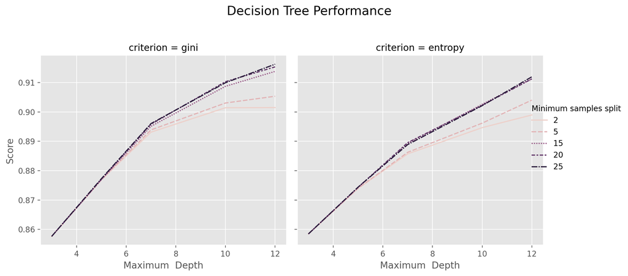

```python
results_DT = pd.DataFrame.from_dict(gs_DT.cv_results_['params'])
results_DT['score'] = gs_DT.cv_results_['mean_test_score']

rel_plot = sns.relplot(
    data=results_DT, x="max_depth", y="score",
    col="criterion", hue="min_samples_split", style="min_samples_split",
    kind="line"
)
rel_plot.axes[0,0].set_xlabel('Maximum  Depth')
rel_plot.axes[0,1].set_xlabel('Maximum  Depth')
rel_plot.axes[0,0].set_ylabel('Score')
rel_plot._legend.set_title("Minimum samples split")
rel_plot._legend._legend_box.align = "left"
rel_plot.fig.subplots_adjust(top=0.8)
rel_plot.fig.suptitle('Decision Tree Performance', fontsize=16)
plt.show(rel_plot)
```

[Back to Table of Contents](#back)

#### Random Forest with Three Parameters Tuning

Aside from the first two classifiers, we also perform hyperparameter tuning for the `Random Forest Classifier` using `GridSearchCV`. The parameter grid includes different values for the `number of estimators`, `maximum depth`, and `criterion`. As usual, GridSearchCV is configured with our cross-validation method and the `roc_auc` scoring metric. After fitting the model on the training data, we identify the best parameters and their corresponding score.

```python
# Define the Random Forest classifier
rf_classifier = RandomForestClassifier(random_state=999)

# Define the hyperparameter grid
params_RF = {'n_estimators': [100, 250, 500],
             'max_depth': [5, 10, 15],
             'criterion': ['gini', 'entropy']}

# Initialise GridSearchCV
gs_RF = GridSearchCV(estimator=rf_classifier,
                     param_grid=params_RF,
                     cv=cv_method_train,
                     scoring=scoring_metric,
                     verbose=1,
                     n_jobs=-1)

# Perform GridSearchCV
gs_RF.fit(D_train_smote, T_train_smote)

# Print best parameters and best score
print(f'The best parameters of Random Forest Classifier are: {gs_RF.best_params_}')
print(f'With the best score using {scoring_metric} as the metric is: {round(gs_RF.best_score_, 3)}')
```

```
Fitting 5 folds for each of 18 candidates, totalling 90 fits
The best parameters of Random Forest Classifier are: {'criterion': 'gini', 'max_depth': 15, 'n_estimators': 500}
With the best score using roc_auc as the metric is: 0.982
```

Though it takes the longest time to compute compared to the previous models, the `Random Forest Classifier` with `500 trees`, a `maximum depth of 15`, and using the `Gini` impurity criterion achieved an outstanding ROC-AUC score of 0.982, making it the best-performing model so far.

Next, we will create a dataframe to store the tested parameters and their test scores. To visualise the results, we will use a line plot to show the relationship between maximum depth, score, criterion, and the number of estimators. This visualisation will help us understand how different hyperparameters affect the performance of the Random Forest Classifier.

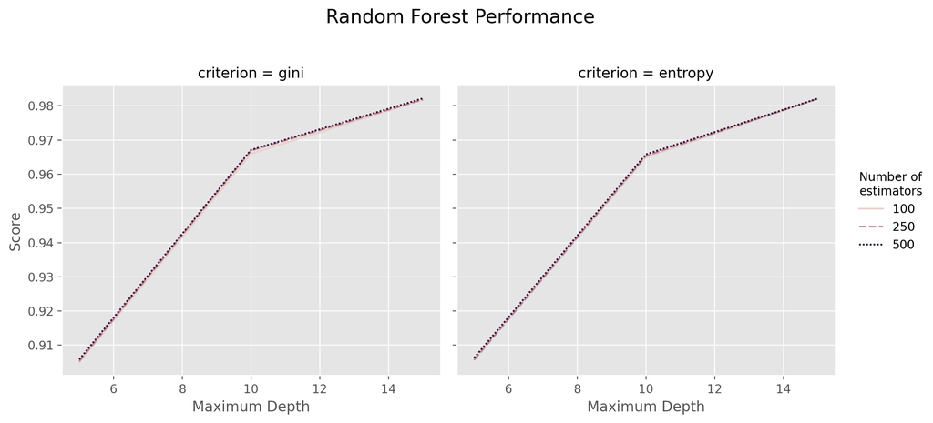

```python
results_RF = pd.DataFrame.from_dict(gs_RF.cv_results_['params'])
results_RF['score'] = gs_RF.cv_results_['mean_test_score']

rel_plot = sns.relplot(
    data=results_RF, x="max_depth", y="score",
    col="criterion", hue="n_estimators", style="n_estimators",
    kind="line"
)
rel_plot.axes[0,0].set_xlabel('Maximum Depth')
rel_plot.axes[0,1].set_xlabel('Maximum Depth')
rel_plot.axes[0,0].set_ylabel('Score')
rel_plot._legend.set_title("Number of\nestimators")
rel_plot._legend._legend_box.align = "left"
rel_plot.fig.subplots_adjust(top=0.8)
rel_plot.fig.suptitle('Random Forest Performance', fontsize=16)
plt.show(rel_plot)
```

[Back to Table of Contents](#back)

#### Naive Bayes with One Parameter Tuning

We also perform hyperparameter tuning for the `Naive Bayes Classifier` using `GridSearchCV`. The parameter grid focuses on `var_smoothing` values, exploring a range from 10 to 0.01 on a logarithmic scale. To improve model performance, we will apply a `PowerTransformer` to the training data for feature transformation. After fitting the transformed training data to the model, we can identify the optimal var_smoothing parameter and its corresponding score.

```python
from sklearn.preprocessing import PowerTransformer

# Initialise and fit the PowerTransformer to the training data
pt = PowerTransformer()
D_Train_fs_transformed = pt.fit_transform(D_train_smote)

# Define the Naive Bayes classifier
nb_classifier = GaussianNB()

# Define the hyperparameter grid
params_NB = {'var_smoothing': np.logspace(1, -2, num=50)}

# Initialise GridSearchCV
gs_NB = GridSearchCV(estimator=nb_classifier,
                     param_grid=params_NB,
                     cv=cv_method_train,
                     scoring=scoring_metric,
                     verbose=1,
                     n_jobs=-1)

# Perform GridSearchCV
gs_NB.fit(D_Train_fs_transformed, T_train_smote)

# Print best parameters and best score
print(f'The best parameters of Naive Bayes Classifier are: {gs_NB.best_params_}')
print(f'With the best score using {scoring_metric} as the metric is: {round(gs_NB.best_score_, 3)}')
```

```
Fitting 5 folds for each of 50 candidates, totalling 250 fits
The best parameters of Naive Bayes Classifier are: {'var_smoothing': 0.07196856730011521}
With the best score using roc_auc as the metric is: 0.862
```

As a result, the `Naive Bayes Classifier` with a `variance smoothing` parameter of approximately `0.072` achieved a respectable ROC-AUC score of 0.862, indicating decent performance, but not as competitive as the previous models.

We will then creates a dataframe to store the tested var_smoothing values and their mean test scores. Lastly, we will plot the relationship between var_smoothing and the mean CV score, visualising the performance of the Naive Bayes Classifier across different parameter values.

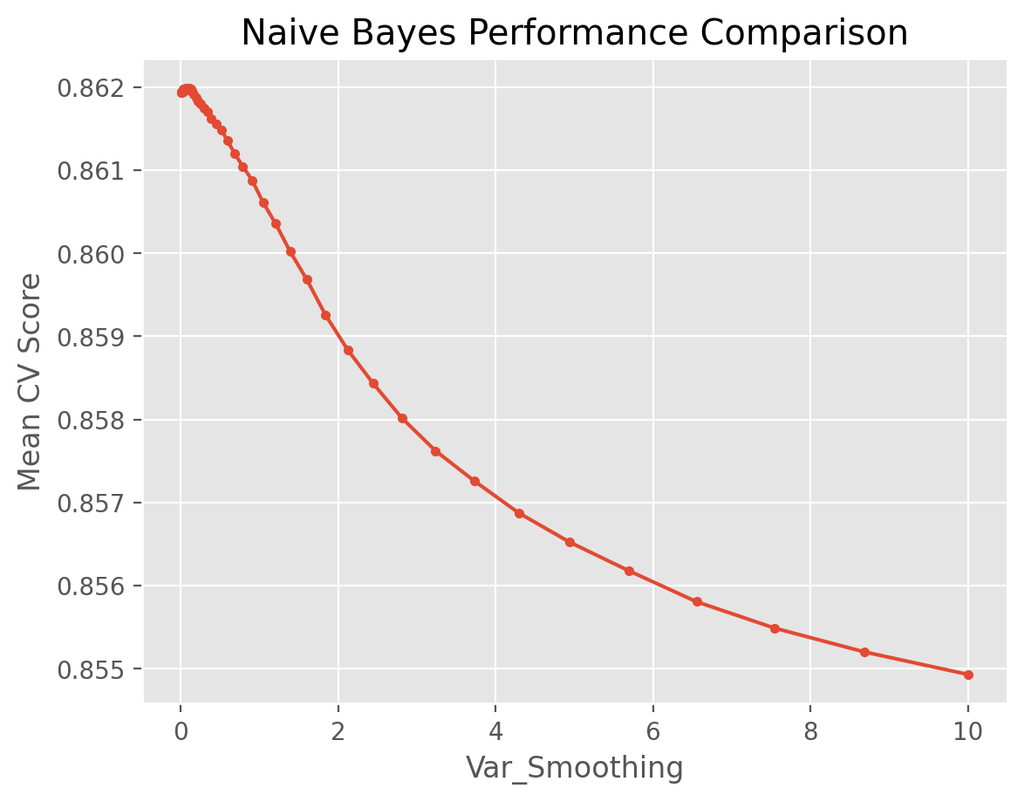

```python
results_NB = pd.DataFrame(gs_NB.cv_results_['params'])
results_NB['test_score'] = gs_NB.cv_results_['mean_test_score']

plt.plot(results_NB['var_smoothing'], results_NB['test_score'], marker = '.')
plt.xlabel('Var_Smoothing')
plt.ylabel("Mean CV Score")
plt.title("Naive Bayes Performance Comparison")
plt.show()
```

[Back to Table of Contents](#back)

#### Logistic Regression with Three Parameters Tuning

We also conduct a grid search to tune hyperparameters for a `Logistic Regression Classifier`. We explore different combinations of three hyperparameters: `C (regularisation parameter)`, `penalty (regularisation type)`, and `solver' (algorithm used in optimisation problem)`. The C parameter controls the strength of regularisation, with a smaller value indicating stronger regularisation. We will test six values for C, ranging from 0.001 to 100, two options for penalty ('l1' and 'l2'), and two choices for 'solver' ('liblinear' and 'saga'). We utilise 5-fold stratified cross-validation to evaluate model performance using the roc_auc as the scoring metric.

```python
from sklearn.linear_model import LogisticRegression
from sklearn.model_selection import GridSearchCV

# Define the logistic regression classifier
logistic_reg = LogisticRegression()

# Define the hyperparameter grid
params_logis = {
    'C': [0.001, 0.01, 0.1, 1, 10, 100],  # Regularization parameter
    'penalty': ['l1', 'l2'],               # Regularization type
    'solver': ['liblinear', 'saga']        # Algorithm to use in optimization problem
}

# Perform grid search with cross-validation
gs_Logis = GridSearchCV(estimator=logistic_reg,
                        param_grid=params_logis,
                        cv=cv_method_train,
                        verbose=1,
                        scoring=scoring_metric)

# Fit the grid search to the data
gs_Logis.fit(D_train_smote, T_train_smote)

# Print the best parameters and the best score
print(f'The best parameters of Logistic Regression Classifier are: {gs_Logis.best_params_}')
print(f'With the best score using {scoring_metric} as the metric is: {round(gs_Logis.best_score_,3)}')
```

```
Fitting 5 folds for each of 24 candidates, totalling 120 fits
The best parameters of Logistic Regression Classifier are: {'C': 0.1, 'penalty': 'l2', 'solver': 'saga'}
With the best score using roc_auc as the metric is: 0.864
```

As a result, the `Logistic Regression Classifier` with an `L2 penalty`, a regularisation parameter `C of 0.1`, and the `SAGA solver` achieved a ROC-AUC score of 0.864, showing good performance, yet not as high as K-Nearest Neighbours or Random Forest.

Following the grid search, we can identify the best combination of hyperparameters that maximise the mean cross-validated roc_auc score. The results will be visualised using line plots, illustrating the performance of the logistic regression classifier across different values of C, penalty, and solver.

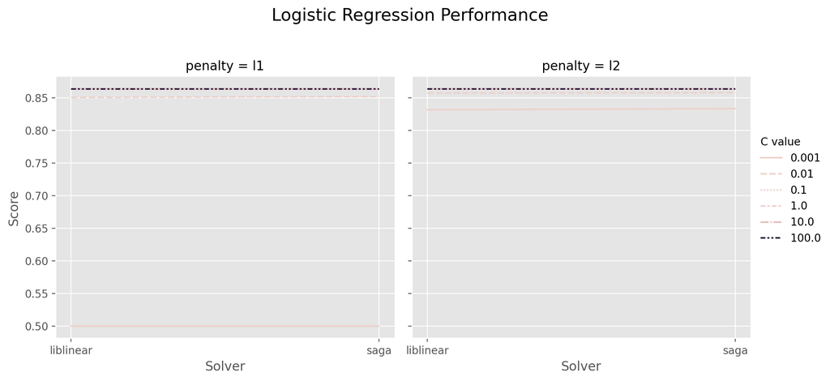

```python
results_Logis = pd.DataFrame.from_dict(gs_Logis.cv_results_['params'])
results_Logis['score'] = gs_Logis.cv_results_['mean_test_score']

rel_plot = sns.relplot(
    data=results_Logis, x="solver", y="score",
    col="penalty", hue="C", style="C",
    kind="line"
)
rel_plot.axes[0,0].set_xlabel('Solver')
rel_plot.axes[0,1].set_xlabel('Solver')
rel_plot.axes[0,0].set_ylabel('Score')
rel_plot._legend.set_title("C value")
rel_plot._legend._legend_box.align = "left"
rel_plot.fig.subplots_adjust(top=0.8)
rel_plot.fig.suptitle('Logistic Regression Performance', fontsize=16)
plt.show(rel_plot)
```

[Back to Table of Contents](#back)

#### Neural Network Model Fitting & Tuning

`A Neural Network (NN) model`, inspired by the neural structure of the human brain, is a complex computational tool used in various machine learning applications. These models consist of layers of interconnected nodes, or neurons, which process and transform data by recognising patterns and relationships. Neural Networks are particularly preferable at handling complicated tasks such as image and speech recognition, natural language processing, and time series forecasting due to their ability to learn and model nonlinear relationships in data. (Abid Ali Awan, 2023)

In our case, we utilise a Neural Network model to tackle a classification problem. The first step in this process is installing and importing necessary packages. As the packages are ready, we can begin with splitting the dataset into training and testing sets. Given the imbalanced nature of our data, we will apply the Synthetic Minority Over-sampling Technique (SMOTE) to balance the class distribution in the training data. This step is crucial to prevent the model from being biased towards the majority class, which could lead to poor generalisation on unseen data.

```python
# Install tensorflow and scikeras (only need to run once)
!pip install tensorflow
!pip install scikeras
```

```python
import tensorflow as tf
from tensorflow.keras import layers, models
from scikeras.wrappers import KerasClassifier
from sklearn.model_selection import RandomizedSearchCV
```

```
2024-06-02 05:30:34.774710: I tensorflow/core/platform/cpu_feature_guard.cc:210] This TensorFlow binary is optimized to use available CPU instructions in performance-critical operations.
To enable the following instructions: AVX2 FMA, in other operations, rebuild TensorFlow with the appropriate compiler flags.
```

```python
# Split the dataset into training and testing sets
D_train, D_test, T_train, T_test = train_test_split(data_top_features, target, test_size=0.3, random_state=999, stratify=target)

# Apply SMOTE to the training data
smote = SMOTE(random_state=999)
D_train_smote, T_train_smote = smote.fit_resample(D_train, T_train)
```

In addition to balancing the class distribution, we also apply the PowerTransformer to the features. This transformation aims to make the feature distribution more Gaussian-like, which can enhance the performance of many machine learning algorithms, including Neural Network model. Normalising the data in this way can help to stabilise the variance and improve the convergence of gradient descent during model training.

```python
# Apply PowerTransformer to the features
pt = PowerTransformer()
D_train_smote_transformed = pt.fit_transform(D_train_smote)
D_test_transformed = pt.transform(D_test)
```

We will then designs the structure of our Neural Network model. The model structure will include an input layer, followed by three hidden layers with `ReLU (Rectified Linear Unit)` activation functions, which are commonly used due to their ability to introduce nonlinearity while avoiding the vanishing gradient problem. (Jason Brownlee, 2020) To reduce the chance of overfitting, we will incorporate dropout layers, which randomly set a fraction of the input units to zero during training, thus promoting redundancy and robustness in the model. The final layer of the network was a dense layer with a `sigmoid` activation function, suitable for binary classification tasks as it outputs probabilities. (Moez Ali, 2023)

We will run the model using the `Adam optimiser`, known for its efficient handling of large datasets and sparse gradients. (Neha Vishwakarma, 2024) The `binary cross-entropy loss` function will also be chosen due to its appropriateness for binary classification as it measures the performance of the model by comparing the predicted probabilities with the actual class labels. (Shipra Saxena, 2024) We will choose the `Area Under the Curve (AUC)` as our primary evaluation metric due to its effectiveness in assessing the performance of classifiers on imbalanced datasets. AUC provides a measure of how well the model distinguishes between the two classes across all possible classification thresholds.

```python
# Code adapted from https://machinelearningmastery.com/tutorial-first-neural-network-python-keras/

def create_model(neurons=64, learning_rate=0.001, dropout_rate=0.5):
    model = models.Sequential()
    model.add(layers.Dense(neurons, activation='relu', input_shape=(D_train_smote_transformed.shape[1],)))
    model.add(layers.Dropout(dropout_rate))
    model.add(layers.Dense(64, activation='relu'))
    model.add(layers.Dropout(dropout_rate))
    model.add(layers.Dense(32, activation='relu'))
    model.add(layers.Dropout(dropout_rate))
    model.add(layers.Dense(1, activation='sigmoid'))  # For binary classification

    optimizer = tf.keras.optimizers.Adam(learning_rate=learning_rate)
    model.compile(optimizer=optimizer,
                  loss='binary_crossentropy',
                  metrics=[tf.keras.metrics.AUC(name='auc')])
    return model
```

We will be using `KerasClassifier` as our model. To further enhance the model's performance, we will conduct hyperparameter tuning using `RandomizedSearchCV`. Because hyperparameters are settings used to control the learning process and the structure of the model, finding the optimal combination can significantly impact the model's performance. Therefore, we will define a grid of five hyperparameters, including the `number of neurons` in each layer, the `learning rate`, the `dropout rate`, the `batch size`, and the `number of epochs`. By performing a randomised search, we can test various combinations of these hyperparameters to evaluate their performance based on AUC scores. This approach will allow us to efficiently explore a wide range of hyperparameter values without the exhaustive computational cost of a grid search.

```python
# Wrap the model using KerasClassifier
model = KerasClassifier(model=create_model, verbose=0)

# Define the hyperparameters grid
param_grid = {
    'model__neurons': [32, 64, 128],
    'model__learning_rate': [0.001, 0.01, 0.1],
    'model__dropout_rate': [0.3, 0.5, 0.7],
    'batch_size': [32, 64, 128],
    'epochs': [50, 100, 150]
}

# Code adapted from https://scikit-learn.org/stable/modules/generated/sklearn.model_selection.RandomizedSearchCV.html

# Use RandomizedSearchCV for hyperparameter tuning
random_search = RandomizedSearchCV(estimator=model, param_distributions=param_grid,
                                   n_iter=20, cv=3, verbose=2, random_state=999,
                                   n_jobs=-1, scoring='roc_auc')

# Perform the hyperparameter search
random_search_result = random_search.fit(D_train_smote_transformed, T_train_smote)
```

```
Fitting 3 folds for each of 20 candidates, totalling 60 fits
```

[output not shown]

```
[CV] END batch_size=64, epochs=150, model__dropout_rate=0.5, model__learning_rate=0.01, model__neurons=64; total time= 1.1min
```

[output not shown]

```
[CV] END batch_size=32, epochs=150, model__dropout_rate=0.5, model__learning_rate=0.01, model__neurons=128; total time= 1.7min
[CV] END batch_size=32, epochs=150, model__dropout_rate=0.5, model__learning_rate=0.01, model__neurons=128; total time= 1.7min
[CV] END batch_size=32, epochs=150, model__dropout_rate=0.5, model__learning_rate=0.01, model__neurons=128; total time= 1.7min
```

[output not shown]

Once the best hyperparameters are identified, we will re-train the model using these settings and evaluated its performance on the test set. This evaluation provided insights into the model's ability to generalise to new or unseen data.

```python
# Print the best parameters and the best score
print(f'Best parameters found: {random_search_result.best_params_}')
print(f'Best AUC score: {random_search_result.best_score_}')

# Extract the best model and evaluate it on the test data
best_model = random_search_result.best_estimator_.model_
test_loss, test_auc = best_model.evaluate(D_test_transformed, T_test)
print(f'Test AUC: {test_auc}')
```

```
Best parameters found: {'model__neurons': 128, 'model__learning_rate': 0.001, 'model__dropout_rate': 0.3, 'epochs': 150, 'batch_size': 64}
Best AUC score: 0.9572430808855718
47/47 ━━━━━━━━━━━━━━━━━━━━ 0s 2ms/step - auc: 0.6775 - loss: 0.5731
Test AUC: 0.7137003540992737
```

The model achieves the best AUC score of 0.957 on the validation data during cross-validation. However, the model's performance on the test data yields an AUC score of only 0.714, indicating a difference between training and testing phases. This difference could potentially be overfitting, where the model performs well on the training data but does not generalise as effectively to new or unseen data.

Finally, we will visualise the effects of different hyperparameters on the model's AUC score. We will generate plots showing the mean AUC scores against each hyperparameter value to understand their impact on the model's performance. These visualisations were crucial for interpreting the tuning process and understanding which hyperparameters had the most significant effect on the model's performance.

```python
# Plotting the results of the hyperparameter tuning

# Plot the effects of each hyperparameter on AUC
results = random_search_result.cv_results_
param_names = list(param_grid.keys())

# Function to plot the effect of a hyperparameter
def plot_hyperparameter_effect(param_name):
    param_values = results[f'param_{param_name}'].data
    mean_test_scores = results['mean_test_score']

    plt.figure(figsize=(10, 6))
    plt.scatter(param_values, mean_test_scores)
    plt.plot(param_values, mean_test_scores, 'o-')

    # Find the index of the highest AUC score
    max_index = mean_test_scores.argmax()
    max_param_value = param_values[max_index]
    max_mean_test_score = mean_test_scores[max_index]

    # Annotate the highest point with its value
    plt.text(max_param_value, max_mean_test_score, f'{max_mean_test_score:.3f}', fontsize=12, ha='right', color='red')
    plt.scatter([max_param_value], [max_mean_test_score], color='red')  # Highlight the highest point

    plt.xlabel(param_name)
    plt.ylabel('Mean AUC Score')
    plt.title(f'Effect of {param_name} on AUC')
    plt.grid(True)
    plt.show()
```

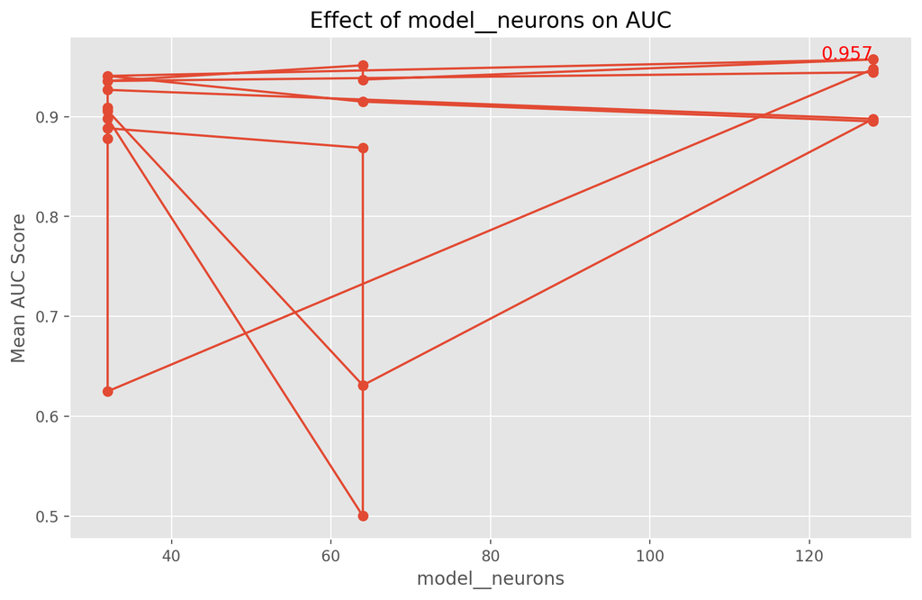

```python
# Plot for number of neurons
plot_hyperparameter_effect('model__neurons')
```

Increasing the number of neurons generally enhances the model's capacity to learn complex patterns, but only up to a point. Beyond this, the risk of overfitting rises as the model may become too complex and start memorising the training data rather than generalising from it. The optimal neuron count (128) indicates a balanced network complexity that supports effective learning without overfitting.

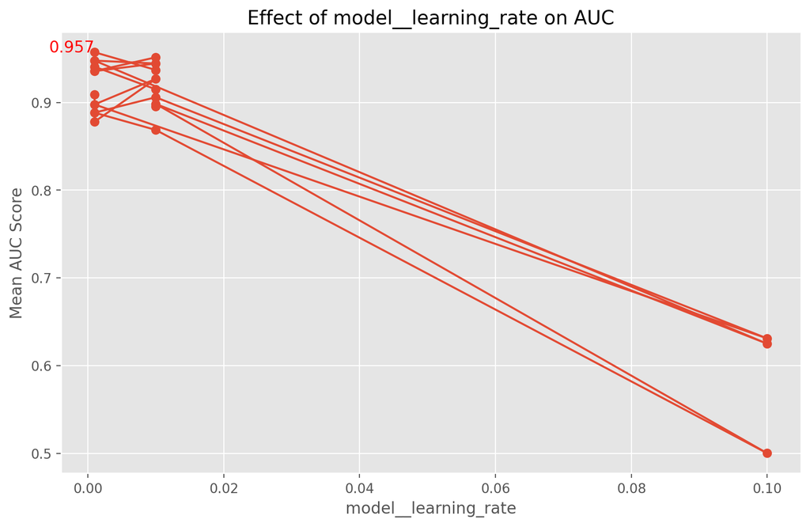

```python
# Plot for learning rate
plot_hyperparameter_effect('model__learning_rate')
```

A lower learning rate might result in a slow convergence, potentially not reaching the optimal point within the given number of epochs. Conversely, a too-high learning rate can cause the model to overshoot the optimal point, leading to suboptimal performance. The optimal learning rate identified (0.001 - The plot does not show precisely, but we can check with the tuning values, where they are 0.001, 0.01, or 0.1) represents a balance, providing a smooth and efficient convergence to an optimal or near-optimal solution.

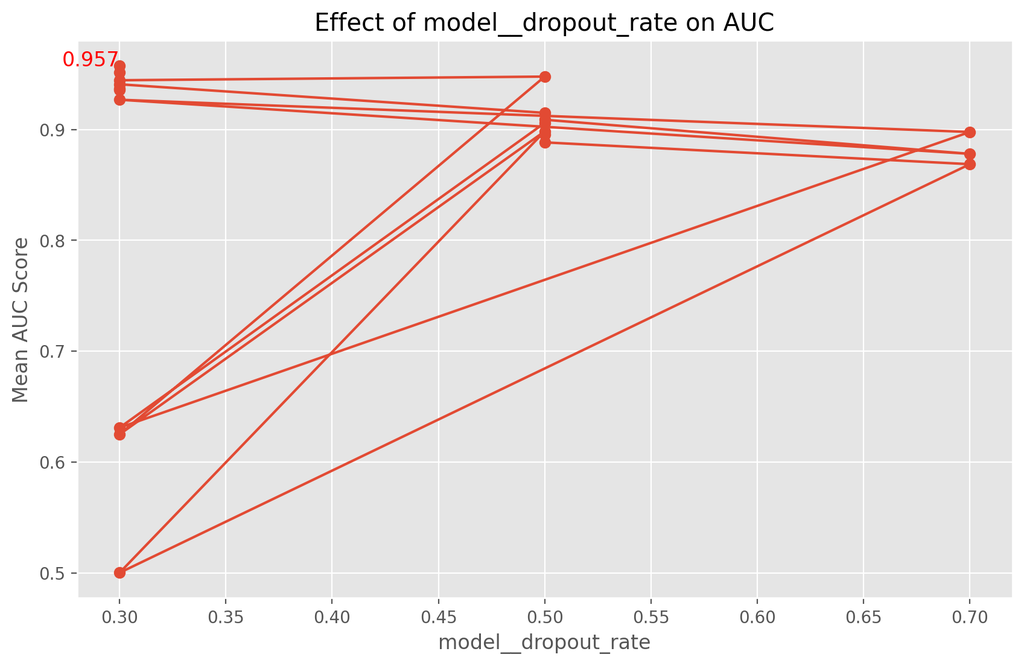

```python
# Plot for dropout rate
plot_hyperparameter_effect('model__dropout_rate')
```

Dropout is a regularisation technique used to prevent overfitting by randomly dropping units during training. A dropout rate that is too low might not sufficiently regularise the model, while a too-high dropout rate can hinder the model's ability to learn. The identified optimal dropout rate (0.3) suggests an effective balance, ensuring the model remains robust without excessively limiting its learning capacity.

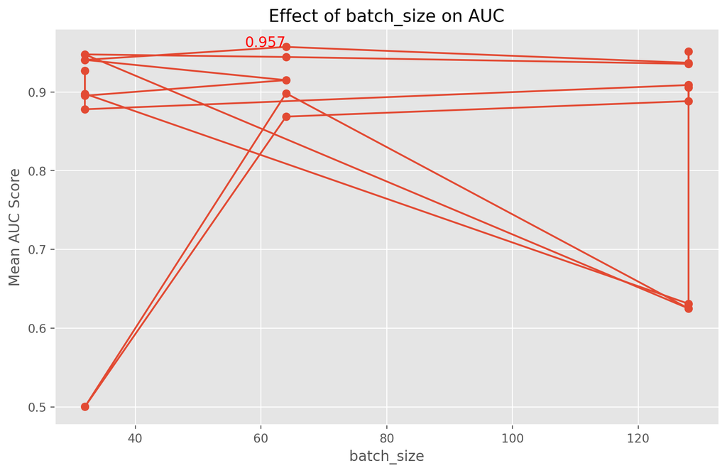

```python
# Plot for batch size
plot_hyperparameter_effect('batch_size')
```

Batch size influences the stability and speed of the training process. Smaller batches provide a regular gradient update but may introduce noise, while larger batches offer smoother updates but require more memory and may lead to slower learning dynamics. The optimal batch size (64) reflects a compromise between these factors, enabling efficient and effective training.

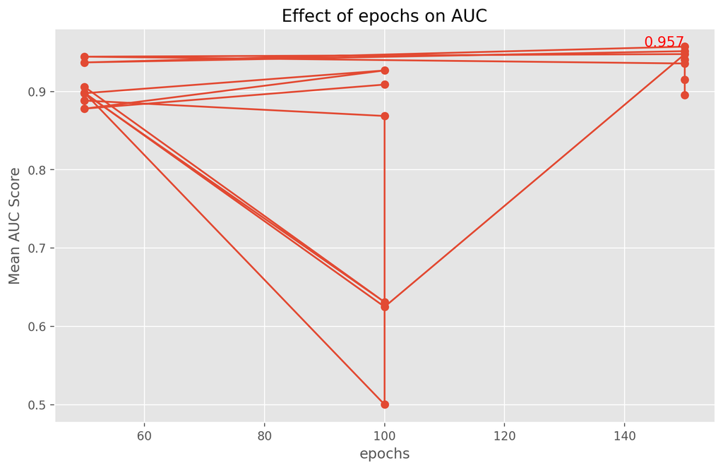

```python
# Plot for number of epochs
plot_hyperparameter_effect('epochs')
```

The number of epochs determines how many times the model iterates over the entire training dataset. Too few epochs may result in underfitting, where the model has not sufficiently learned from the data. Too many epochs can lead to overfitting. The chosen 150 epochs indicate a thorough training process, allowing the model to learn adequately while still balancing the risk of overfitting.

[Back to Table of Contents](#back)

Random Forest stands out with the highest ROC-AUC score of 0.982, indicating it is the best at distinguishing between classes while K-Nearest Neighbours (KNN) and Neural Network (Keras) follow with an impressive score of 0.961 and 0.957 respectively, showing strong performance. Decision Tree also shows a good performance with a ROC-AUC score of 0.916, but it might not be as robust as Random Forest. Logistic Regression and Naive Bayes have similar ROC-AUC scores (0.864 and 0.862 respectively), indicating they are slightly less effective than the other models in this comparison.

The visualisation for the comparison of each model is shown below:

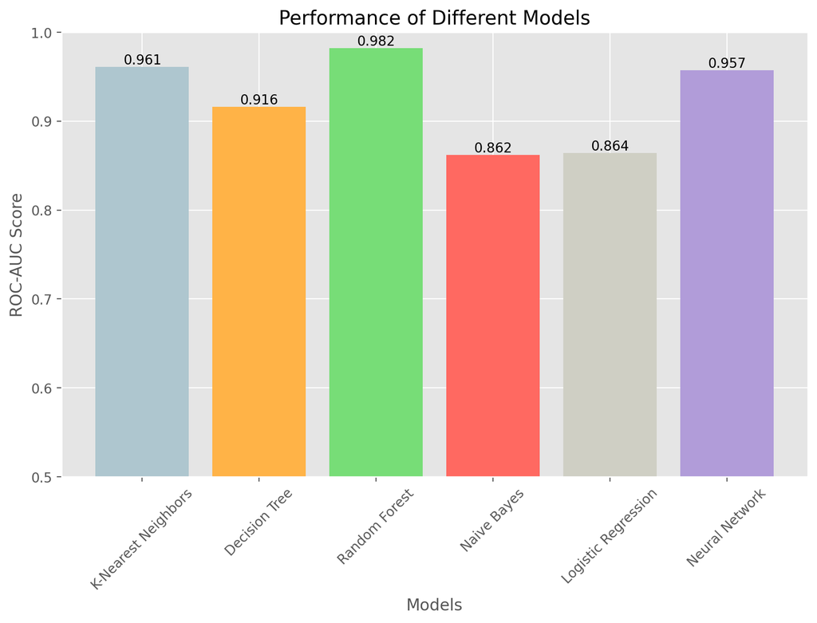

```python
import matplotlib.pyplot as plt

# Create lists to store model names and their corresponding scores
models = ['K-Nearest Neighbors', 'Decision Tree', 'Random Forest', 'Naive Bayes', 'Logistic Regression', 'Neural Network']
roc_auc_scores = [0.961, 0.916, 0.982, 0.862, 0.864, 0.957]

# Plotting the ROC-AUC scores
plt.figure(figsize=(10, 6))
bars = plt.bar(models, roc_auc_scores, color=['#AEC6CF', '#FFB347', '#77DD77', '#FF6961', '#CFCFC4', '#B19CD9'])
plt.xlabel('Models')
plt.ylabel('ROC-AUC Score')
plt.title('Performance of Different Models')
plt.ylim(0.5, 1.0)
plt.xticks(rotation=45)

# Add numeric labels to the bars
for bar in bars:
    height = bar.get_height()
    plt.text(bar.get_x() + bar.get_width() / 2, height, round(height, 3), ha='center', va='bottom')

plt.show()
```

[Back to Table of Contents](#back)

### Model Comparison

To compare the algorithms' performance using paired t-tests, we need to collect the cross-validation scores for each model and then perform statistical tests to determine if there are significant differences between the models. Firstly, we will perform cross-validation on each model and store the ROC-AUC scores. Then, we will compare the models using paired t-tests on their cross-validation scores.

```python
from tensorflow.keras import layers, models
from sklearn.model_selection import cross_val_score

# Function to create the neural network model
def create_nn_model(neurons=128, learning_rate=0.001, dropout_rate=0.3):
    model = models.Sequential()
    model.add(layers.Dense(neurons, activation='relu', input_shape=(D_train_smote.shape[1],)))
    model.add(layers.Dropout(dropout_rate))
    model.add(layers.Dense(neurons, activation='relu'))
    model.add(layers.Dropout(dropout_rate))
    model.add(layers.Dense(1, activation='sigmoid'))

    model.compile(optimizer=tf.keras.optimizers.Adam(learning_rate=learning_rate),
                  loss='binary_crossentropy',
                  metrics=[tf.keras.metrics.AUC(name='auc')])
    return model

# Wrap the model using KerasClassifier
nn_classifier = KerasClassifier(build_fn=create_nn_model, epochs=150, batch_size=64, verbose=0)

# Apply PowerTransformer to D_train_smote
D_train_smote_transformed = PowerTransformer().fit_transform(D_train_smote)

# Perform cross-validation for the neural network model
nn_scores = cross_val_score(nn_classifier, D_train_smote_transformed, T_train_smote, cv=cv_method_train, scoring='roc_auc')

# Cross-validation scores for other models
knn_classifier = KNeighborsClassifier(n_neighbors=9, p=1, weights='distance')
knn_scores = cross_val_score(knn_classifier, D_train_smote, T_train_smote, cv=cv_method_train, scoring='roc_auc')

dt_classifier = DecisionTreeClassifier(criterion='gini', max_depth=12, min_samples_split=25, random_state=999)
dt_scores = cross_val_score(dt_classifier, D_train_smote, T_train_smote, cv=cv_method_train, scoring='roc_auc')

rf_classifier = RandomForestClassifier(criterion='gini', max_depth=15, n_estimators=500, random_state=999)
rf_scores = cross_val_score(rf_classifier, D_train_smote, T_train_smote, cv=cv_method_train, scoring='roc_auc')

nb_classifier = GaussianNB(var_smoothing=0.07196856730011521)
nb_scores = cross_val_score(nb_classifier, D_train_smote_transformed, T_train_smote, cv=cv_method_train, scoring='roc_auc')

logistic_reg = LogisticRegression(C=0.1, penalty='l2', solver='saga', random_state=999)
logis_scores = cross_val_score(logistic_reg, D_train_smote, T_train_smote, cv=cv_method_train, scoring='roc_auc')

# Print Cross-validation scores
print("K-Nearest Neighbors ROC-AUC Scores:", knn_scores)
print("Decision Tree ROC-AUC Scores:", dt_scores)
print("Random Forest ROC-AUC Scores:", rf_scores)
print("Naive Bayes ROC-AUC Scores:", nb_scores)
print("Logistic Regression ROC-AUC Scores:", logis_scores)
print("Neural Network ROC-AUC Scores:", nn_scores)
```

[output not shown]

[output cut: 21 more lines]

To do the comparison, we will use `ttest_rel` from `scipy.stats` to perform paired t-tests between the models.

And to interpret the results, a higher absolute value of `t-statistic` indicates a greater difference between the paired samples while `p-value` points out the significance. If the p-value is less than the significance level (0.05), we conclude that there is a significant difference between the models.

```python
from scipy.stats import ttest_rel

# Paired t-tests
def paired_ttest(scores1, scores2, model1, model2):
    t_stat, p_value = ttest_rel(scores1, scores2)
    print(f'Paired t-test between {model1} and {model2}: \nt-statistic = {t_stat:.3f} \np-value = {p_value:.3f}\n')
    return t_stat, p_value

# Compare K-Nearest Neighbors with other models
paired_ttest(knn_scores, dt_scores, 'K-Nearest Neighbors', 'Decision Tree')
paired_ttest(knn_scores, rf_scores, 'K-Nearest Neighbors', 'Random Forest')
paired_ttest(knn_scores, nb_scores, 'K-Nearest Neighbors', 'Naive Bayes')
paired_ttest(knn_scores, logis_scores, 'K-Nearest Neighbors', 'Logistic Regression')
paired_ttest(knn_scores, nn_scores, 'K-Nearest Neighbors', 'Neural Network')

# Compare Decision Tree with other models
paired_ttest(dt_scores, rf_scores, 'Decision Tree', 'Random Forest')
paired_ttest(dt_scores, nb_scores, 'Decision Tree', 'Naive Bayes')
paired_ttest(dt_scores, logis_scores, 'Decision Tree', 'Logistic Regression')
paired_ttest(dt_scores, nn_scores, 'Decision Tree', 'Neural Network')

# Compare Random Forest with other models
paired_ttest(rf_scores, nb_scores, 'Random Forest', 'Naive Bayes')
paired_ttest(rf_scores, logis_scores, 'Random Forest', 'Logistic Regression')
paired_ttest(rf_scores, nn_scores, 'Random Forest', 'Neural Network')

# Compare Naive Bayes with other models
paired_ttest(nb_scores, logis_scores, 'Naive Bayes', 'Logistic Regression')
paired_ttest(nb_scores, nn_scores, 'Naive Bayes', 'Neural Network')

# Compare Logistic Regression with Neural Network
paired_ttest(logis_scores, nn_scores, 'Logistic Regression', 'Neural Network')
```

```
Paired t-test between K-Nearest Neighbors and Decision Tree:
t-statistic = 23.121
p-value = 0.000

Paired t-test between K-Nearest Neighbors and Random Forest:
t-statistic = -8.480
p-value = 0.001

Paired t-test between K-Nearest Neighbors and Naive Bayes:
t-statistic = 30.965
p-value = 0.000

Paired t-test between K-Nearest Neighbors and Logistic Regression:
t-statistic = 32.185
p-value = 0.000

Paired t-test between K-Nearest Neighbors and Neural Network:
t-statistic = -1.859
p-value = 0.137

Paired t-test between Decision Tree and Random Forest:
t-statistic = -17.712
p-value = 0.000

Paired t-test between Decision Tree and Naive Bayes:
t-statistic = 14.017
p-value = 0.000

Paired t-test between Decision Tree and Logistic Regression:
t-statistic = 14.470
p-value = 0.000

Paired t-test between Decision Tree and Neural Network:
t-statistic = -20.109
p-value = 0.000

Paired t-test between Random Forest and Naive Bayes:
t-statistic = 46.635
p-value = 0.000

Paired t-test between Random Forest and Logistic Regression:
t-statistic = 60.731
p-value = 0.000

Paired t-test between Random Forest and Neural Network:
t-statistic = 13.634
p-value = 0.000

Paired t-test between Naive Bayes and Logistic Regression:
t-statistic = 2.201
p-value = 0.093

Paired t-test between Naive Bayes and Neural Network:
t-statistic = -32.979
p-value = 0.000

Paired t-test between Logistic Regression and Neural Network:
t-statistic = -36.228
p-value = 0.000
```

```
(-36.227911997603854, 3.4655745395029453e-06)
```

#### Summary

Based on this summary, `Random Forest` is the best-performing model in terms of ROC-AUC scores. Therefore, it should be the model of choice for this classification problem. The results suggest that tuning the hyperparameters of the Random Forest model has yielded a highly effective model, outperforming the other algorithms tested.

[Back to Table of Contents](#back)

## `Critique & Limitations`

### Weaknesses

- While SMOTE (Synthetic Minority Over-sampling Technique) was used to balance the target classes, it is important to acknowledge that it can sometimes generate noisy samples that may not accurately represent the minority class. (Ibraheem M Alkhawaldeh et al., 2023) This noise can potentially degrade model performance rather than improve it. Therefore, it would be wise to consider other resampling techniques or ensemble methods for comparison. Exploring other alternatives can provide a more comprehensive understanding of the best approach to handle class imbalance in the dataset.
- The dataset used for training and evaluation might not capture all possible scenarios encountered in real-world applications. This limitation can affect the model's ability to generalise well to unseen data. To address this, further validation on different datasets is crucial. By testing the model on diverse and representative datasets, we can ensure its robustness and reliability in various real-world contexts, consequently improving its practical applicability and performance.
- Hyperparameter tuning, particularly with GridSearchCV, can be computationally expensive and time-consuming. (Bala Priya C, 2023) This is especially true for models like Random Forest, which can involve a large number of trees, or K-Nearest Neighbours, which can be challenging with large datasets. The extensive search over a wide range of hyperparameters requires significant computational resources and time. To handle this, other efficient techniques could be considered, which may offer a balance between computational efficiency and thorough exploration of the hyperparameter space.
- Despite the use of cross-validation, there is always a risk of overfitting, particularly with complex models and extensive hyperparameter tuning. Overfitting occurs when a model learns the training data too well, including its noise and outliers, which can negatively impact its performance on unseen data. (Akruti Acharya, 2024) To manage this, it is essential to conduct further validation and potentially consider simpler models that are less prone to overfitting.

[Back to Table of Contents](#back)

## `Summary & Conclusions`

### Project Summary

#### Phase 1: Data Preparation & Visualisation

Initially, we read the dataset and perform preliminary inspection to understand its structure and content. The dataset contained a variety of features, including demographic information, health-related variables, and the target variable (stroke). To ensure the data is suitable for analysis, we converted categorical features to appropriate formats and handled missing bmi values.

To understand the distribution of categorical features, we created bar charts for gender, marital_status, and residence_type. These bar charts not only displayed the counts of each category but also included percentage labels for a better interpretation. Kernel Density Estimates (KDE) plots were used to visualise the distributions of continuous features (age, bmi, and avg_glucose_level). These plots included mean lines to highlight the central tendencies of the distributions.

Further analysis focused on health-related variables. Bar charts with percentages were created for smoking_status and heart_disease, as well as the distribution of stroke occurrences by gender. We also compared stroke occurrences by smoking status using a categorical plot, and Ridge plots were created to compare the distributions of age, bmi, and avg_glucose_level between individuals with and without strokes.

In addition, Scatter plots were used to explore the relationship between bmi and avg_glucose_level, together with a grouped bar chart that was created to show the number of individuals with hypertension, heart disease, and stroke by marital status. We also used a combined boxplot to see the distribution of average glucose levels by smoking status and gender for individuals who had a stroke. Last but not leaset, logistic regression plots were created to examine the impact of heart_disease and hypertension on stroke occurrence across different age groups and genders.

Through these visualisations, we gained valuable information about the relationships between different features and stroke occurrences, which can be helpful in applying the dataset in predictive modelling in the next phase.

#### Phase 2: Predictive Modelling

We first loaded and prepared the dataset retrieved from the previous phase by encoding categorical variables using one-hot encoding. We normalised numerical features to ensure consistency across the dataset. We examined data distributions and feature relationships with the target variable. Feature engineering involved selecting relevant features based on domain knowledge and initial insights. We discovered a significant class imbalance in the target variable, with the minority class representing only 4.26% of the data. To address this, we applied the Synthetic Minority Over-sampling Technique (SMOTE) to create synthetic samples for the minority class, achieving a balanced dataset.

### Summary of Findings

Paired t-tests indicated significant performance differences between most model pairs, with Random Forest consistently outperforming the others. Neural Network and K-Nearest Neighbours significantly outperformed Decision Tree, Naive Bayes, and Logistic Regression. No significant difference was found between Naive Bayes and Logistic Regression, indicating similar performance.

### Conclusions

The Random Forest model emerged as the top-performing algorithm for predicting stroke risk, achieving the highest ROC-AUC score and demonstrating significant statistical superiority over other models. Key features such as avg_glucose_level, bmi, and age were identified as crucial predictors, underscoring their importance. The application of SMOTE effectively addressed class imbalance, leading to improved performance and more reliable predictions for the minority class. Hyperparameter tuning via GridSearchCV optimised model performance, highlighting its critical role. However, the study may face limitations including potential overfitting, computational costs, and assumptions in statistical tests. Future work could explore advanced models, broader hyperparameter searches, and additional preprocessing techniques to enhance performance and robustness.

Overall, the project successfully validated the Random Forest model as the most effective for predicting stroke risk, offering valuable insights into feature importance and addressing key challenges like data imbalance.

[Back to Table of Contents](#back)

## `References`

Abid Ali Awan. (2023). What are Neural Networks? Retrieved from https://www.datacamp.com/blog/what-are-neural-networks

Akruti Acharya. (2024). Overfitting in Machine Learning: How to Detect and Avoid Overfitting in Computer Vision? Retrieved from https://encord.com/blog/overfitting-in-machine-learning/

Bala Priya C. (2023). Hyperparameter Tuning: GridSearchCV and RandomizedSearchCV, Explained. Retrieved from https://www.kdnuggets.com/hyperparameter-tuning-gridsearchcv-and-randomizedsearchcv-explained

Chloe Turner. (2024). K Fold Cross Validation In Machine Learning. Retrieved from https://www.theknowledgeacademy.com/blog/k-fold-cross-validation-in-machine-learning/

FEDESORIANO. (2021). Stroke Prediction Dataset. Retrieved from https://www.kaggle.com/datasets/fedesoriano/stroke-prediction-dataset/data

Ibraheem M Alkhawaldeh, Ibrahem Albalkhi, and Abdulqadir Jeprel Naswhan. (2023). Challenges and limitations of synthetic minority oversampling techniques in machine learning. Retrieved from https://www.ncbi.nlm.nih.gov/pmc/articles/PMC10789107/

Jason Brownlee. (2020). A Gentle Introduction to the Rectified Linear Unit (ReLU). Retrieved from https://machinelearningmastery.com/rectified-linear-activation-function-for-deep-learning-neural-networks/

Jason Brownlee. (2021). Tour of Evaluation Metrics for Imbalanced Classification. Retrieved from https://machinelearningmastery.com/tour-of-evaluation-metrics-for-imbalanced-classification/

Leonard Dieguez. (2023). Why use Area under the curve? (AUC - ROC). Retrieved from https://www.mlrelated.com/showarticle/1575.php

Moez Ali. (2023). Introduction to Activation Functions in Neural Networks. Retrieved from https://www.datacamp.com/tutorial/introduction-to-activation-functions-in-neural-networks

Neha Vishwakarma. (2024). What is Adam Optimizer? Retrieved from https://www.analyticsvidhya.com/blog/2023/09/what-is-adam-optimizer/

Pierian Training. (2023). GridSearchCV with Scikit-Learn and Python. Retrieved from https://pieriantraining.com/gridsearchcv-with-scikit-learn-and-python/

Rahul Shah. (2024). Tune Hyperparameters with GridSearchCV. Retrieved from https://www.analyticsvidhya.com/blog/2021/06/tune-hyperparameters-with-gridsearchcv/

Shipra Saxena. (2024). Binary Cross Entropy/Log Loss for Binary Classification. Retrieved from https://www.analyticsvidhya.com/blog/2021/03/binary-cross-entropy-log-loss-for-binary-classification/

SWASTIK SATPATHY. (2023). SMOTE for Imbalanced Classification with Python. Retrieved from https://www.analyticsvidhya.com/blog/2020/10/overcoming-class-imbalance-using-smote-techniques/

[Back to Table of Contents](#back)